# **ЛАБОРАТОРНА РОБОТА №3**

## **Дисципліна:** *Data Science*

### **Тема:** *Оцінка рівня безпекового розвитку країн світу (глобальні загрози)*

### **Виконали:** Сімоненко Анастасія, Ільїн Сергій, Каширський Арсеній

### **Групи:** КІ-33, КІ-32

## **Мета роботи**

Провести комплексну оцінку рівня безпекового розвитку країн світу на основі багатовимірного аналізу даних, включаючи вибір індикаторів, підготовку та нормалізацію даних, побудову моделей та інтерпретацію результатів.

## **Етапи виконання роботи**

1. Огляд існуючих рішень та методологій.
2. Побудова концептуальної моделі та вибір індикаторів (не менше 6).
3. Формування вибірки з ≥50 країн та ≥15 років, обробка пропусків, багатовимірний аналіз.
4. Нормалізація даних, побудова моделі (PCA, кластеризація).
5. Формування звітності: огляд, сирі дані, оброблені дані, презентація.

## **Короткий опис роботи**

У межах лабораторної проведено збір, підготовку та аналіз міжнародних даних щодо військових, соціальних, політичних та екологічних загроз. Використано методи PCA та кластеризації для визначення груп країн зі схожими профілями безпекових ризиків.

# **РОЗДІЛ 1. ОГЛЯД ІСНУЮЧИХ РІШЕНЬ**

Оцінювання рівня безпекового розвитку країн є важливою складовою глобальної аналітики, яка дозволяє порівнювати держави за масштабом загроз, рівнем стабільності та вразливості до конфліктів. Огляд міжнародних підходів є критичним етапом, оскільки дозволяє визначити найбільш інформативні індикатори та сформувати комплексну модель.

## **1. Основні міжнародні індекси безпеки**

### **1. Global Peace Index (GPI)**

**Джерело:** Institute for Economics & Peace  
**Спрямування:** рівень мирності та конфліктності країни.

Враховує:

- внутрішню безпеку та кримінал
- політичну стабільність
- військову активність
- оборонні витрати
- участь у конфліктах

**Переваги:** глобальне охоплення, структурованість.  
**Недоліки:** високий рівень агрегації → складно аналізувати окремі загрози.

### **2. Fragile States Index (FSI)**

**Джерело:** Fund for Peace  
**Спрямування:** оцінка вразливості держав.

Включає:

- біженців та внутрішньо переміщених осіб
- групове насильство
- нерівність
- корупцію
- безпеку населення

**Переваги:** деталізує внутрішню нестабільність.  
**Недоліки:** частина індикаторів якісна → обмеження кількісного аналізу.

### **3. World Governance Indicators (WGI)**

**Джерело:** World Bank  
**Спрямування:** інституційна якість управління.

Показники:

- політична стабільність
- ефективність уряду
- верховенство права
- контроль корупції

### **4. Uppsala Conflict Data Program (UCDP)**

**Спрямування:** детальний опис збройних конфліктів.

Містить дані про:

- кількість загиблих
- типи конфліктів
- сторони протистояння

### **5. Global Terrorism Database (GTD)**

**Спрямування:** події тероризму.

Містить:

- понад 200 000 інцидентів
- види атак, жертви, локації
- дані з 1970 року

### **6. Internal Displacement Monitoring Centre (IDMC)**

Дані про внутрішньо переміщених осіб внаслідок:

- конфліктів
- насильства
- природних катастроф

## **2. Порівняння підходів**

| Індекс | Спрямування | Переваги | Недоліки | Що використовуємо в моделі |
| --- | --- | --- | --- | --- |
| GPI | Мирність, конфлікти | Широке охоплення | Надмірна агрегація | військові, соціальні індикатори |
| FSI | Вразливість, стабільність | Глибина аналізу | Частина якісних даних | демографія, корупція, насилля |
| WGI | Інституційна якість | Кількісні показники | Повільна оновлюваність | політична стабільність |
| UCDP | Збройні конфлікти | Найточніші дані про втрати | Вузький фокус | conflict deaths |
| GTD | Тероризм | Деталізація | Висока варіативність | terrorism intensity |
| IDMC | Переміщення людей | Актуальність | Нерівномірне покриття | IDPs |

## **3. Підсумковий висновок**

Існуючі міжнародні індекси або інтегрують дані у великий агрегований бал, або зосереджуються на окремих сферах (конфлікти, управління, кримінал).

**У цій роботі сформовано власну багатовимірну модель, яка поєднує дані з різних джерел та дозволяє кластеризувати країни за їх комплексним безпековим профілем.**

> *Рис. 1.*

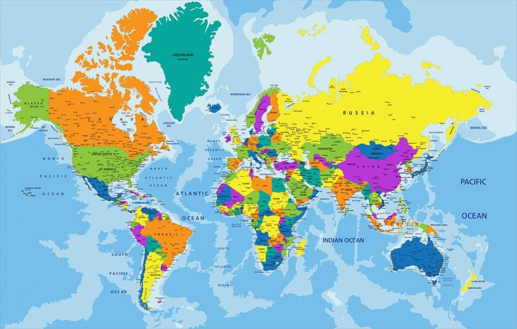

# **РОЗДІЛ 2. КОНЦЕПТУАЛЬНА МОДЕЛЬ ОЦІНКИ БЕЗПЕКОВОГО РОЗВИТКУ**

Концептуальна модель розроблена для системної оцінки рівня безпекового розвитку країн світу.  
Вона поєднує військові, гуманітарні, соціальні та інституційні індикатори, що дозволяє розглядати безпеку не лише як військову стабільність, а як комплексний багатовимірний феномен.

Нижче подано структуру моделі та логіку вибору індикаторів.

## **2.1. Структура моделі**

Модель складається з **трьох груп загроз**, що охоплюють різні аспекти безпеки:

### **1) Воєнно-політичні загрози**

| Індикатор | Що вимірює |
| --- | --- |
| **MilitaryExp_GDP** | Частка військових витрат у ВВП → рівень мілітаризації держави |
| **TerrorismDeaths** | Кількість загиблих від тероризму → інтенсивність терористичної активності |
| **ConflictDeaths** | Загиблі у збройних конфліктах → масштабність бойових дій |
| **InternalDisplacement_Total** | Внутрішньо переміщені особи → гуманітарні наслідки та небезпека для цивільного населення |

### **2) Соціально-кримінальні загрози**

| Індикатор | Що вимірює |
| --- | --- |
| **HomicideRate** | Рівень умисних вбивств → криміногенна ситуація та внутрішня безпека |

### **3) Інституційна стійкість**

[output not shown]

Усього: **7 індикаторів → більше за мінімально необхідні 6**, що відповідає вимогам роботи.

## **2.2. Візуальна схема моделі**

```
graph TD
    A[БЕЗПЕКОВИЙ РОЗВИТОК] --> B[Воєнно-політичні загрози]
    A --> C[Соціально-кримінальні загрози]
    A --> D[Інституційна стійкість]

    B --> B1[MilitaryExp_GDP]
    B --> B2[TerrorismDeaths]
    B --> B3[ConflictDeaths]
    B --> B4[InternalDisplacement]

    C --> C1[HomicideRate]

    D --> D1[Governance1]
    D --> D2[Governance2]
```

## **3.1. Завантаження даних: Military Expenditure (% of GDP)**

У цьому підрозділі завантажуються дані зі світового банку щодо частки військових витрат у ВВП.  
Формат файлу - CSV з багаторічними спостереженнями по країнах.

```python
# Ігноруємо warnings
import warnings

# Ігнорувати всі попередження
warnings.filterwarnings('ignore')

# Oоб Pandas не сварився на SettingWithCopy
import pandas as pd
pd.options.mode.chained_assignment = None
```

```python
# -----------------------------------------
# РОЗДІЛ 3: ПІДГОТОВКА ДАНИХ
# 3.1 Military Expenditure (% of GDP)
# -----------------------------------------

import pandas as pd

# 1) Завантаження сирих даних із World Bank
mil_raw = pd.read_csv(
    "raw_data/API_MS.MIL.XPND.GD.ZS_DS2_en_csv_v2_216288.csv",
    skiprows=4  # пропускаємо службові рядки
)

# 2) Перетворення даних у формат Country–Year–Value
mil = mil_raw.melt(
    id_vars=["Country Name", "Country Code"],
    var_name="Year",
    value_name="MilitaryExp_GDP"
)

# 3) Видаляємо нечислові роки та конвертуємо тип
mil = mil[mil["Year"].str.isnumeric()]
mil["Year"] = mil["Year"].astype(int)

# 4) Зберігаємо оброблені дані у новий файл
mil.to_csv("processed_data/military.csv", index=False)

# 5) Відображення перших рядків
mil.head()
```

|  | Country Name | Country Code | Year | MilitaryExp_GDP |
| --- | --- | --- | --- | --- |
| 532 | Aruba | ABW | 1960 | NaN |
| 533 | Africa Eastern and Southern | AFE | 1960 | NaN |
| 534 | Afghanistan | AFG | 1960 | NaN |
| 535 | Africa Western and Central | AFW | 1960 | NaN |
| 536 | Angola | AGO | 1960 | NaN |

**Висновок:**  
Дані про військові витрати успішно завантажено, очищено та приведено у формат “довгої таблиці”.  
Цей набір використовується як ключовий індикатор у групі *воєнно-політичних загроз*.

## **3.2. Завантаження даних: Intentional Homicides (per 100k population)**

У цьому підрозділі обробляється показник рівня умисних убивств на 100 000 населення.  
Цей індикатор використовується для оцінки **соціально-кримінальних загроз**, оскільки він відображає як рівень насильства, так і загальну безпекову ситуацію всередині держави.

**Кроки обробки:**

1. Завантаження сирого CSV-файлу.
2. Перетворення широкого формату на довгий (melt).
3. Фільтрація валідних років.
4. Конвертація типу змінної року.
5. Збереження очищеної таблиці у папку processed_data.

```python
# -----------------------------------------
# РОЗДІЛ 3: ПІДГОТОВКА ДАНИХ
# 3.2 Intentional Homicides (per 100k)
# -----------------------------------------

# 1) Завантаження даних з World Bank
hom_raw = pd.read_csv(
    "raw_data/API_VC.IHR.PSRC.P5_DS2_en_csv_v2_128274.csv",
    skiprows=4  # пропускаємо службові метадані
)

# 2) Перетворення у формат Country–Year–Value
hom = hom_raw.melt(
    id_vars=["Country Name", "Country Code"],
    var_name="Year",
    value_name="HomicideRate"
)

# 3) Фільтрація наявних числових років
hom = hom[hom["Year"].str.isnumeric()]
hom["Year"] = hom["Year"].astype(int)

# 4) Збереження очищених даних
hom.to_csv("processed_data/homicide_clean.csv", index=False)

# 5) Виведення перших рядків таблиці
hom.head()
```

|  | Country Name | Country Code | Year | HomicideRate |
| --- | --- | --- | --- | --- |
| 532 | Aruba | ABW | 1960 | NaN |
| 533 | Africa Eastern and Southern | AFE | 1960 | NaN |
| 534 | Afghanistan | AFG | 1960 | NaN |
| 535 | Africa Western and Central | AFW | 1960 | NaN |
| 536 | Angola | AGO | 1960 | NaN |

**Висновок:**  
Показник *Intentional Homicides (per 100k)* успішно очищено та приведено до уніфікованого формату.  
Цей індикатор виступає ключовим елементом блоку **соціально-кримінальних загроз**, оскільки демонструє рівень насильницьких злочинів у країнах світу.

## **3.3. Завантаження даних: Governance Indicators (WGI)**

У цьому підрозділі завантажуються дані з World Governance Indicators (WGI),  
які включають оцінку політичної стабільності, якості уряду, верховенства права та контролю корупції.

Першим кроком є попереднє ознайомлення з набором даних:  
перевірка колонок, структури та доступних серій (Series Name), оскільки файл WGI містить багато змінних й необхідно вибрати лише ті, що потрібні для нашої моделі.

```python
# ---------------------------------------------------------
# РОЗДІЛ 3: ПІДГОТОВКА ДАНИХ
# 3.3 Governance Indicators - перевірка структури
# ---------------------------------------------------------

# 1) Завантаження сирого набору WGI
gov_raw = pd.read_csv("raw_data/e45ea223-9cd6-4478-b814-ffe09ec550f0_Data.csv")

# 2) Перевіряємо доступні серії показників
gov_raw["Series Name"].unique()
```

```
array(['Control of Corruption: Estimate',
       'Control of Corruption: Number of Sources',
       'Control of Corruption: Percentile Rank',
       'Control of Corruption: Percentile Rank, Lower Bound of 90% Confidence Interval',
       'Control of Corruption: Percentile Rank, Upper Bound of 90% Confidence Interval',
       'Control of Corruption: Standard Error',
       'Government Effectiveness: Estimate',
       'Government Effectiveness: Number of Sources',
       'Government Effectiveness: Percentile Rank',
       'Government Effectiveness: Percentile Rank, Lower Bound of 90% Confidence Interval',
       'Government Effectiveness: Percentile Rank, Upper Bound of 90% Confidence Interval',
       'Government Effectiveness: Standard Error',
       'Political Stability and Absence of Violence/Terrorism: Estimate',
       'Political Stability and Absence of Violence/Terrorism: Number of Sources',
       'Political Stability and Absence of Violence/Terrorism: Percentile Rank',
       'Political Stability and Absence of Violence/Terrorism: Percentile Rank, Lower Bound of 90% Confidence Interval',
       'Political Stability and Absence of Violence/Terrorism: Percentile Rank, Upper Bound of 90% Confidence Interval',
       'Political Stability and Absence of Violence/Terrorism: Standard Error',
       'Regulatory Quality: Estimate',
       'Regulatory Quality: Number of Sources',
       'Regulatory Quality: Percentile Rank',
       'Regulatory Quality: Percentile Rank, Lower Bound of 90% Confidence Interval',
       'Regulatory Quality: Percentile Rank, Upper Bound of 90% Confidence Interval',
       'Regulatory Quality: Standard Error', 'Rule of Law: Estimate',
       'Rule of Law: Number of Sources', 'Rule of Law: Percentile Rank',
       'Rule of Law: Percentile Rank, Lower Bound of 90% Confidence Interval',
       'Rule of Law: Percentile Rank, Upper Bound of 90% Confidence Interval',
       'Rule of Law: Standard Error',
       'Voice and Accountability: Estimate',
       'Voice and Accountability: Number of Sources',
       'Voice and Accountability: Percentile Rank',
       'Voice and Accountability: Percentile Rank, Lower Bound of 90% Confidence Interval',
       'Voice and Accountability: Percentile Rank, Upper Bound of 90% Confidence Interval',
       'Voice and Accountability: Standard Error', nan], dtype=object)
```

**Проміжний висновок:**  
Перевірено список доступних індикаторів у наборі даних WGI.  
На наступному кроці будуть обрані потрібні змінні (Governance1, Governance2),  
а також виконано фільтрацію, агрегування та приведення даних до формату Country-Year-Value.

### **3.3.1. Перевірка структури та формату даних WGI**

Після первинного завантаження даних з World Governance Indicators  
необхідно перевірити структуру CSV-файлу: назви колонок, типи змінних  
та формат років.

Цей крок є критичним, оскільки у наборі WGI часто зустрічається проблема:  
**роки зберігаються не у класичному числовому форматі, а у вигляді стовпців з текстовими назвами**  
(наприклад, `"1996"`, `"2000"`, `"2002"` тощо).

Саме некоректний формат року і став причиною того, що дані спочатку «не вигружалися»  
або не піддавалися трансформації через melt.

```python
gov_raw.columns
#шукали помилку, чому не вигружаються данні - через формат року
```

```
Index(['Country Name', 'Country Code', 'Series Name', 'Series Code',
       '1996 [YR1996]', '1998 [YR1998]', '2000 [YR2000]', '2002 [YR2002]',
       '2003 [YR2003]', '2004 [YR2004]', '2005 [YR2005]', '2006 [YR2006]',
       '2007 [YR2007]', '2008 [YR2008]', '2009 [YR2009]', '2010 [YR2010]',
       '2011 [YR2011]', '2012 [YR2012]', '2013 [YR2013]', '2014 [YR2014]',
       '2015 [YR2015]', '2016 [YR2016]', '2017 [YR2017]', '2018 [YR2018]',
       '2019 [YR2019]', '2020 [YR2020]', '2021 [YR2021]', '2022 [YR2022]',
       '2023 [YR2023]'],
      dtype='object')
```

**Проміжний висновок:**  
Структура набору даних підтверджує, що роки зберігаються як окремі текстові колонки,  
а не як числовий стовпець `Year`.  
Тому перед об'єднанням або аналізом WGI необхідно:

- відфільтрувати потрібні Series Name,
- виконати операцію melt для перетворення даних у формат Country-Year-Value,
- привести роки до числового типу.

На наступному кроці будемо вибирати два показники Governance1 та Governance2.

### **3.3.2. Обробка Governance Indicators (WGI)**

Для оцінки інституційної стійкості держав у цьому дослідженні використовуються два індикатори з World Governance Indicators:

- **Government Effectiveness: Estimate** → *Governance1*
- **Political Stability and Absence of Violence/Terrorism: Estimate** → *Governance2*

Особливістю WGI є те, що роки подано у вигляді окремих колонок з текстовими назвами  
(наприклад, `"2003 [YR2003]"`).  
Тому перед аналізом необхідно:

1. Виділити всі річні колонки.
2. Привести набір даних до довгого формату (Country-Year-Value).
3. Очистити формат року регулярними виразами.
4. Зберегти результати в окремі файли.

Нижче наведено повний процес обробки індикаторів.

```python
import re

# читаю WGI
gov_raw = pd.read_csv("raw_data/e45ea223-9cd6-4478-b814-ffe09ec550f0_Data.csv")

# витягую всі колонки років (починаються з цифри)
year_cols = [c for c in gov_raw.columns if c[0].isdigit()]

# функція для "довгого" формату
def melt_gov(df, value_name):
    g = df.melt(
        id_vars=["Country Code"],
        value_vars=year_cols,
        var_name="Year",
        value_name=value_name
    )

    # (чистка) колонка рік: "2003 [YR2003]" → 2003
    g["Year"] = g["Year"].apply(lambda x: int(re.findall(r'\d{4}', x)[0]))

    return g

# Government Effectiveness
gov1_raw = gov_raw[gov_raw["Series Name"] == "Government Effectiveness: Estimate"]
gov1 = melt_gov(gov1_raw, "Governance1")

# Political Stability
gov2_raw = gov_raw[gov_raw["Series Name"] == "Political Stability and Absence of Violence/Terrorism: Estimate"]
gov2 = melt_gov(gov2_raw, "Governance2")

# зберігаємо
gov1.to_csv("raw_data/governance1.csv", index=False)
gov2.to_csv("raw_data/governance2.csv", index=False)

gov1.head(), gov2.head()
```

```
(  Country Code  Year        Governance1
 0          AFG  1996  -2.17516660690308
 1          ALB  1996  -0.68858790397644
 2          DZA  1996  -1.08876645565033
 3          ASM  1996                 ..
 4          AND  1996   1.41403770446777,
   Country Code  Year         Governance2
 0          AFG  1996   -2.41730952262878
 1          ALB  1996  -0.336625128984451
 2          DZA  1996   -1.78331053256989
 3          ASM  1996                  ..
 4          AND  1996    1.16952216625214)
```

**Проміжний висновок:**  
Показники *Government Effectiveness* та *Political Stability* успішно очищено та приведено до уніфікованого формату.  
Обидва індикатори використовуються в моделі як складові блоків **інституційної стійкості**.

У наступних кроках вони будуть об'єднані з іншими наборами даних для побудови фінальної таблиці.

## **3.4. Завантаження даних: Terrorism Deaths (Global Terrorism Database)**

Global Terrorism Database (GTD) - найбільша у світі база подій тероризму,  
що містить понад 200 000 записів з **1970 по 2020 роки**.  
Для оцінки терористичної активності використовуємо змінну **nkill**,  
яка відображає кількість загиблих у кожному інциденті.

У цьому підрозділі виконуємо:

1. Завантаження GTD у форматі Excel.
2. Вибір основних колонок: рік, країна, кількість загиблих.
3. Агрегацію смертності по країні та року.
4. Перейменування змінних до стандартного формату моделі.
5. Збереження очищених даних.

```python
# 3.4 Terrorism Deaths (GTD)
gtd = pd.read_excel("raw_data/globalterrorismdb_0522dist.xlsx", engine="openpyxl")

# Вибираємо основні колонки
terror = gtd[["iyear", "country_txt", "nkill"]]

# Агрегуємо смертність по країні та року
terror = terror.groupby(["country_txt", "iyear"])["nkill"].sum().reset_index()

# Перейменовуємо колонки
terror = terror.rename(columns={
    "country_txt": "Country",
    "iyear": "Year",
    "nkill": "TerrorismDeaths"
})

# Зберігаємо
terror.to_csv("raw_data/terrorism.csv", index=False)

terror.head()
```

|  | Country | Year | TerrorismDeaths |
| --- | --- | --- | --- |
| 0 | Afghanistan | 1973 | 0.0 |
| 1 | Afghanistan | 1979 | 53.0 |
| 2 | Afghanistan | 1987 | 0.0 |
| 3 | Afghanistan | 1988 | 128.0 |
| 4 | Afghanistan | 1989 | 10.0 |

**Висновок:**  
Дані GTD успішно оброблено: смертність від терористичних атак агреговано по країні та року.  
Цей показник використовується у моделі як один з ключових індикаторів **воєнно-політичних загроз**.

```python
# 3.5 Conflict Deaths (UCDP) дивлюсь структуру - через помилку
ucdp = pd.read_csv("raw_data/BattleDeaths_v25_1_conf.csv")
ucdp.columns
```

```
Index(['conflict_id', 'dyad_id', 'location_inc', 'side_a', 'side_a_id',
       'side_a_2nd', 'side_b', 'side_b_id', 'side_b_2nd', 'incompatibility',
       'territory_name', 'year', 'bd_best', 'bd_low', 'bd_high',
       'type_of_conflict', 'battle_location', 'gwno_a', 'gwno_a_2nd', 'gwno_b',
       'gwno_b_2nd', 'gwno_loc', 'gwno_battle', 'region', 'version'],
      dtype='object')
```

## **3.5. Завантаження даних: Conflict Deaths (UCDP Battle-Related Deaths)**

Uppsala Conflict Data Program (UCDP) - це найбільш авторитетний набір даних  
щодо смертності у збройних конфліктах у світі.  
У цьому дослідженні використовується таблиця **Battle-Related Deaths**,  
яка містить інформацію про кількість загиблих у бойових зіткненнях за країнами та роками.

Особливості набору:

- країна може мати кілька записів за один рік (різні сторони конфлікту),
- тому необхідна **агрегація смертності по країні та року**,
- змінна `bd_best` використовується як найбільш надійна оцінка втрат.

У цьому підрозділі виконується:

1. Завантаження даних.
2. Вибір релевантних колонок.
3. Перейменування змінних у стандартизований формат.
4. Агрегація смертності по країні та року.
5. Збереження очищеної таблиці.

```python
# 3.5 Conflict Deaths (UCDP) - правильні колонки
ucdp = pd.read_csv("raw_data/BattleDeaths_v25_1_conf.csv")

ucdp_small = ucdp[["location_inc", "year", "bd_best"]]

# перейменовуємо
ucdp_small = ucdp_small.rename(columns={
    "location_inc": "Country",
    "year": "Year",
    "bd_best": "ConflictDeaths"
})

# сумуємо смертність, якщо у країни декілька записів за рік
ucdp_agg = ucdp_small.groupby(["Country", "Year"])["ConflictDeaths"].sum().reset_index()

# зберігаємо
ucdp_agg.to_csv("raw_data/conflict.csv", index=False)

ucdp_agg.head()
```

|  | Country | Year | ConflictDeaths |
| --- | --- | --- | --- |
| 0 | Afghanistan | 1989 | 5174 |
| 1 | Afghanistan | 1990 | 1478 |
| 2 | Afghanistan | 1991 | 3302 |
| 3 | Afghanistan | 1992 | 4276 |
| 4 | Afghanistan | 1993 | 3721 |

**Висновок:**  
Дані UCDP успішно очищено, стандартизовано та агреговано.  
Показник *ConflictDeaths* є одним із найбільш критичних індикаторів  
у групі **воєнно-політичних загроз**, оскільки напряму характеризує інтенсивність бойових дій у країнах.

## **3.6. Завантаження даних: Internal Displacement (IDMC)**

Internal Displacement Monitoring Centre (IDMC) - основне міжнародне джерело  
даних про внутрішньо переміщених осіб (IDPs), спричинених:

- збройними конфліктами,
- насильством,
- природними катастрофами.

Цей показник дозволяє оцінити **гуманітарний вимір загроз** і є важливою складовою нашої моделі.

У цьому підрозділі проводиться:

1. Завантаження даних у форматі Excel.
2. Вибір ключових колонок: країна, рік, переміщення через конфлікти і катастрофи.
3. Перейменування змінних у стандартизований формат.
4. Створення інтегрального показника `InternalDisplacement_Total`.
5. Збереження оброблених даних.

```python
# ---------------------------------------------------------
# РОЗДІЛ 3: ПІДГОТОВКА ДАНИХ
# 3.6 Internal Displacement (IDMC)
# ---------------------------------------------------------

# 1) Завантаження даних IDMC
idmc = pd.read_excel("raw_data/IDMC_Internal_Displacement_Conflict-Violence_Disasters-2.xlsx")

# 2) Вибір ключових колонок:
# ISO3 - код країни
# Name - назва країни
# Year - рік
# Conflict Internal Displacements - IDP через конфлікти
# Disaster Internal Displacements - IDP через стихійні лиха
idmc_small = idmc[[
    "ISO3", "Name", "Year",
    "Conflict Internal Displacements",
    "Disaster Internal Displacements"
]]

# 3) Перейменування у стандартизований формат
idmc_small = idmc_small.rename(columns={
    "ISO3": "Country Code",
    "Name": "Country",
    "Conflict Internal Displacements": "Conflict_IDP",
    "Disaster Internal Displacements": "Disaster_IDP"
})

# 4) Створення інтегрального індикатора TOTAL
idmc_small["InternalDisplacement_Total"] = idmc_small[["Conflict_IDP", "Disaster_IDP"]].sum(axis=1)

# 5) Зберігаємо у processed_data/
idmc_small.to_csv("processed_data/idmc.csv", index=False)

# 6) Перегляд перших рядків
idmc_small.head()
```

|  | Country Code | Country | Year | Conflict_IDP | Disaster_IDP | InternalDisplacement_Total |
| --- | --- | --- | --- | --- | --- | --- |
| 0 | AB9 | Abyei Area | 2024 | 21000.0 | 15000.0 | 36000.0 |
| 1 | AFG | Afghanistan | 2024 | 3200.0 | 1017000.0 | 1020200.0 |
| 2 | AGO | Angola | 2024 | NaN | 85000.0 | 85000.0 |
| 3 | ALB | Albania | 2024 | NaN | 9.0 | 9.0 |
| 4 | AND | Andorra | 2024 | NaN | 5.0 | 5.0 |

**Висновок:**  
Дані IDMC успішно підготовлено: створено інтегральний показник внутрішнього переміщення населення,  
який є ключовим гуманітарним індикатором у групі *воєнно-політичних та соціальних загроз*.  
Він буде використаний у подальшому для багатовимірного аналізу та кластеризації країн.

```python
#очищую папку від зайвих файлів
import os

# Папка з файлами
folder = "raw_data"

# Список файлів, які треба видалити
files_to_delete = [
    "Metadata_Country_API_MS.MIL.XPND.GD.ZS_DS2_en_csv_v2_216288.csv",
    "Metadata_Indicator_API_MS.MIL.XPND.GD.ZS_DS2_en_csv_v2_216288.csv",
    "Metadata_Country_API_VC.IHR.PSRC.P5_DS2_en_csv_v2_128274.csv",
    "Metadata_Indicator_API_VC.IHR.PSRC.P5_DS2_en_csv_v2_128274.csv",
    "e45ea223-9cd6-4478-b814-ffe09ec550f0_Series - Metadata.csv",
    "persons_of_concern.csv",
    "footnotes.csv"
]

deleted = []

for fname in files_to_delete:
    full_path = os.path.join(folder, fname)
    if os.path.exists(full_path):
        os.remove(full_path)
        deleted.append(fname)

deleted
```

```
[]
```

У 3 файлах країна подана не ISO-кодом, а full name:

- terrorism.csv → Country.
- conflict.csv → Country.
- idmc.csv → має і Country, і Country Code (ISO).

Тоді потрібно привести ВСІ індикатори до ISO-коду. Зробимо це автоматично через World Bank Country Codes.

## **3.7. Нормалізація назв країн: завантаження ISO-кодів (Country Codes)**

Під час об’єднання даних із різних джерел виникає проблема:  
кожен набір даних використовує **різні формати назв країн**  
(наприклад, “United States”, “USA”, “United States of America”).

Щоб забезпечити коректне злиття всіх таблиць, необхідно мати **єдиний довідник країн** з уніфікованим ISO-кодом (ISO 3166-1 Alpha-3).

У цьому підрозділі:

1. Завантажується стабільний CSV зі списком країн та ISO-кодів.
2. Обираються лише необхідні колонки.
3. Виконується очищення (видалення рядків без ISO-коду).
4. Файл використовується як словник при об’єднанні даних у наступних кроках.

```python
# РОЗДІЛ 3: ПІДГОТОВКА ДАНИХ
# 3.7 Завантаження та нормалізація ISO-кодів країн

# 1) Стабільне джерело ISO-кодів (GitHub dataset)
url_cc = "https://raw.githubusercontent.com/datasets/country-codes/master/data/country-codes.csv"

# 2) Завантажуємо повний набір
cc = pd.read_csv(url_cc)

# 3) Залишаємо тільки офіційну назву країни та код ISO3
cc = cc[["official_name_en", "ISO3166-1-Alpha-3"]].rename(columns={
    "official_name_en": "Country",
    "ISO3166-1-Alpha-3": "Country Code"
})

# 4) Видаляємо записи без ISO-коду
cc = cc.dropna(subset=["Country Code"])

# 5) Переглядаємо перші рядки словника країн
cc.head()
```

|  | Country | Country Code |
| --- | --- | --- |
| 0 | Afghanistan | AFG |
| 1 | Åland Islands | ALA |
| 2 | Albania | ALB |
| 3 | Algeria | DZA |
| 4 | American Samoa | ASM |

**Проміжний висновок:**  
Створено довідник країн з уніфікованими ISO-кодами, який буде використаний для коректного об’єднання всіх підготовлених наборів даних у єдину таблицю.  
Це забезпечує узгодженість Country/ISO форматів між різними міжнародними джерелами (World Bank, UCDP, GTD, IDMC).

### **3.8. Перевірка структури директорії `raw_data`**

Перед об'єднанням усіх підготовлених наборів даних необхідно перевірити,  
чи всі файли були успішно зчитані та присутні у директорії `raw_data`.

Даний технічний крок дозволяє:

- переконатися, що всі сирі джерела на місці,
- підтвердити коректність шляхів до файлів,
- уникнути помилок при подальших операціях merge.

Нижче виконується автоматичний вивід списку всіх файлів у папці `raw_data`.

```python
import os

os.listdir("raw_data")
```

```
['IDMC_Internal_Displacement_Conflict-Violence_Disasters-2.xlsx',
 'military.csv',
 'conflict.csv',
 'governance1.csv',
 'globalterrorismdb_0522dist.xlsx',
 'BattleDeaths_v25_1_conf.csv',
 'idmc.csv',
 'e45ea223-9cd6-4478-b814-ffe09ec550f0_Data.csv',
 'API_MS.MIL.XPND.GD.ZS_DS2_en_csv_v2_216288.csv',
 '.DS_Store',
 'API_VC.IHR.PSRC.P5_DS2_en_csv_v2_128274.csv',
 'poc.csv',
 'governance2.csv',
 'homicide_clean.csv',
 'terrorism.csv']
```

## **4.1. Завантаження всіх очищених індикаторів**

На цьому етапі всі попередньо оброблені набори даних зчитуються  
із каталогу `raw_data/`, де вони були збережені після етапів очищення.  
Ці таблиці містять стандартизовані показники у форматі Country-Year-Value.

Індикатори, що завантажуються:

- MilitaryExpenditure (% of GDP)
- Homicide Rate
- Governance1 (Government Effectiveness)
- Governance2 (Political Stability)
- Terrorism Deaths (GTD)
- Conflict Deaths (UCDP)
- InternalDisplacement_Total (IDMC)

Усі вони будуть об'єднані у єдину панельну таблицю.

```python
# ---------------------------------------------------------
# РОЗДІЛ 4: ФОРМУВАННЯ ФІНАЛЬНОГО ДАТАФРЕЙМУ
# 4.1 Завантаження всіх очищених індикаторів
# ---------------------------------------------------------

# 1) Воєнні витрати (% ВВП)
mil = pd.read_csv("raw_data/military.csv")

# 2) Умисні вбивства
hom = pd.read_csv("raw_data/homicide_clean.csv")

# 3) Інституційна стійкість
gov1 = pd.read_csv("raw_data/governance1.csv")
gov2 = pd.read_csv("raw_data/governance2.csv")

# 4) Смертність від тероризму
terror = pd.read_csv("raw_data/terrorism.csv")

# 5) Смертність у збройних конфліктах
conflict = pd.read_csv("raw_data/conflict.csv")

# 6) Внутрішнє переміщення
idmc = pd.read_csv("raw_data/idmc.csv")

mil.head(), hom.head(), gov1.head(), gov2.head()
```

```
(                  Country Name Country Code  Year  MilitaryExp_GDP
 0                        Aruba          ABW  1960              NaN
 1  Africa Eastern and Southern          AFE  1960              NaN
 2                  Afghanistan          AFG  1960              NaN
 3   Africa Western and Central          AFW  1960              NaN
 4                       Angola          AGO  1960              NaN,
                   Country Name Country Code  Year  HomicideRate
 0                        Aruba          ABW  1960           NaN
 1  Africa Eastern and Southern          AFE  1960           NaN
 2                  Afghanistan          AFG  1960           NaN
 3   Africa Western and Central          AFW  1960           NaN
 4                       Angola          AGO  1960           NaN,
   Country Code  Year        Governance1
 0          AFG  1996  -2.17516660690308
 1          ALB  1996  -0.68858790397644
 2          DZA  1996  -1.08876645565033
 3          ASM  1996                 ..
 4          AND  1996   1.41403770446777,
   Country Code  Year         Governance2
 0          AFG  1996   -2.41730952262878
 1          ALB  1996  -0.336625128984451
 2          DZA  1996   -1.78331053256989
 3          ASM  1996                  ..
 4          AND  1996    1.16952216625214)
```

**Проміжний висновок:**  
Усі очищені індикатори успішно завантажено.  
Дані готові до операції `merge()` для формування фінального датафрейму.

## **4.3. Мапінг даних Terrorism та Conflict на ISO3-коди**

Дані GTD (тероризм) та UCDP (бойові втрати) містять назви країн  
у текстовому форматі (`Country`).  
Оскільки назви у різних джерелах можуть відрізнятися  
(наприклад: *United States*, *USA*, *United States of America*),  
необхідно перетворити їх на стандартизовані **ISO3-коди**.

Цей етап забезпечує:

- уніфікацію ключів при об’єднанні таблиць,
- уникнення помилок через різні назви країн,
- коректну інтеграцію всіх індикаторів у фінальний датафрейм.

Нижче виконується мапінг для двох таблиць:  
**Terrorism Deaths** (GTD) та **Conflict Deaths** (UCDP).

```python
# ---------------------------------------------------------
# РОЗДІЛ 4: ФОРМУВАННЯ ФІНАЛЬНОГО ДАТАФРЕЙМУ
# 4.3 Мапінг terrorism і conflict на ISO3-коди
# ---------------------------------------------------------

# --- Terrorism (GTD) ---
# Додаємо ISO3-код через merge з таблицею cc (country codes)
terror_iso = terror.merge(cc, on="Country", how="left")

# Видаляємо записи, де ISO-коду не знайдено
terror_iso = terror_iso.dropna(subset=["Country Code"])

# Обираємо стандартизовані колонки
terror_iso = terror_iso[["Country Code", "Year", "TerrorismDeaths"]]

# --- Conflict (UCDP) ---
conflict_iso = conflict.merge(cc, on="Country", how="left")
conflict_iso = conflict_iso.dropna(subset=["Country Code"])
conflict_iso = conflict_iso[["Country Code", "Year", "ConflictDeaths"]]

# Перевіряємо результат
terror_iso.head(), conflict_iso.head()
```

```
(  Country Code  Year  TerrorismDeaths
 0          AFG  1973              0.0
 1          AFG  1979             53.0
 2          AFG  1987              0.0
 3          AFG  1988            128.0
 4          AFG  1989             10.0,
   Country Code  Year  ConflictDeaths
 0          AFG  1989            5174
 1          AFG  1990            1478
 2          AFG  1991            3302
 3          AFG  1992            4276
 4          AFG  1993            3721)
```

**Проміжний висновок:**  
Для наборів Terrorism і Conflict виконано успішне зіставлення країн з ISO3-кодами.  
Це гарантує коректне об'єднання даних на наступних етапах формування фінального датафрейму.

## **4.4. Об’єднання всіх індикаторів у фінальний панельний DataFrame**

Після очищення та уніфікації всіх наборів даних необхідно об’єднати їх у єдину панельну таблицю.  
Усі індикатори використовують однакові ключі:

- **Country Code (ISO3)**
- **Year**

Тому для об’єднання застосовується послідовний `merge()` з типом `outer`, що дозволяє:

- зберегти всі можливі спостереження,
- не втратити дані для країн, де індикаторів може бути менше,
- забезпечити повну структуру панельних даних.

У результаті формується фінальний датафрейм **df**, що містить усі 7 індикаторів моделі.

```python
# ---------------------------------------------------------
# РОЗДІЛ 4: ФОРМУВАННЯ ФІНАЛЬНОГО ДАТАФРЕЙМУ
# 4.4 Об’єднання всіх індикаторів
# ---------------------------------------------------------

# Початкова таблиця - військові витрати (має Country Code, Year)
df = mil.copy()

# Додаємо показник умисних убивств
df = df.merge(hom, on=["Country Code", "Year"], how="outer")

# Додаємо Governance1 (Government Effectiveness)
df = df.merge(gov1, on=["Country Code", "Year"], how="outer")

# Додаємо Governance2 (Political Stability)
df = df.merge(gov2, on=["Country Code", "Year"], how="outer")

# Додаємо смертність від тероризму (після мапінгу на ISO3)
df = df.merge(terror_iso, on=["Country Code", "Year"], how="outer")

# Додаємо смертність у збройних конфліктах (UCDP)
df = df.merge(conflict_iso, on=["Country Code", "Year"], how="outer")

# Додаємо загальну кількість внутрішньо переміщених осіб (IDMC)
df = df.merge(
    idmc[["Country Code", "Year", "InternalDisplacement_Total"]],
    on=["Country Code", "Year"],
    how="outer"
)

df.head(), df.shape
```

```
(  Country Name_x Country Code  Year  MilitaryExp_GDP Country Name_y  \
 0            NaN          AB9  2014              NaN            NaN
 1            NaN          AB9  2015              NaN            NaN
 2            NaN          AB9  2016              NaN            NaN
 3            NaN          AB9  2017              NaN            NaN
 4            NaN          AB9  2018              NaN            NaN

    HomicideRate Governance1 Governance2  TerrorismDeaths  ConflictDeaths  \
 0           NaN         NaN         NaN              NaN             NaN
 1           NaN         NaN         NaN              NaN             NaN
 2           NaN         NaN         NaN              NaN             NaN
 3           NaN         NaN         NaN              NaN             NaN
 4           NaN         NaN         NaN              NaN             NaN

    InternalDisplacement_Total
 0                         0.0
 1                         0.0
 2                         0.0
 3                         0.0
 4                       152.0  ,
 (17566, 11))
```

**Проміжний висновок:**  
Фінальний датафрейм успішно сформовано.  
Він містить усі 7 індикаторів дослідження та панельну структуру даних за країнами та роками.

`df.shape` показує розмір таблиці (кількість рядків та колонок), а `df.head()` дозволяє швидко перевірити коректність об’єднання.

Наступним етапом буде очистка пропусків та формування вибірки з країн і років.

## **4.5. Додавання назв країн та формування фінальної структури таблиці**

На попередніх кроках усі індикатори було об’єднано за ISO3-кодами (`Country Code`).  
Однак для подальшого аналізу та побудови графіків важливо мати також **текстову назву країни**.

Оскільки таблиця IDMC містить найповніший і найчистіший список назв країн,  
саме з неї виконується мапінг назв (`Country`) на ISO3-коди.

Також на цьому етапі:

1. Формується остаточний набір колонок.
2. Залишаються лише спостереження у межах досліджуваного періоду (**2000-2023 роки**).
3. Готується фінальна панельна таблиця для подальшого аналізу, нормалізації та побудови моделей.

```python
# ---------------------------------------------------------
# РОЗДІЛ 4: ФОРМУВАННЯ ФІНАЛЬНОГО ДАТАФРЕЙМУ
# 4.5 Додавання назв країн та вибір фінальних колонок
# ---------------------------------------------------------

# 1) Додаємо назву країни із таблиці IDMC (найбільш чистий реєстр)
country_names = idmc[["Country Code", "Country"]].drop_duplicates()

# 2) Додаємо назви країн до фінального DataFrame
df = df.merge(country_names, on="Country Code", how="left")

# 3) Формуємо остаточний перелік колонок
df = df[[
    "Country Code", "Country", "Year",
    "MilitaryExp_GDP", "HomicideRate",
    "Governance1", "Governance2",
    "TerrorismDeaths", "ConflictDeaths",
    "InternalDisplacement_Total"
]]

# 4) Обмежуємо період дослідження 2000–2023 роками
df = df[df["Year"].between(2000, 2023)]

# Перевіряємо форму та перші рядки
df.head(), df.shape
```

```
(  Country Code     Country  Year  MilitaryExp_GDP  HomicideRate Governance1  \
 0          AB9  Abyei Area  2014              NaN           NaN         NaN
 1          AB9  Abyei Area  2015              NaN           NaN         NaN
 2          AB9  Abyei Area  2016              NaN           NaN         NaN
 3          AB9  Abyei Area  2017              NaN           NaN         NaN
 4          AB9  Abyei Area  2018              NaN           NaN         NaN

   Governance2  TerrorismDeaths  ConflictDeaths  InternalDisplacement_Total
 0         NaN              NaN             NaN                         0.0
 1         NaN              NaN             NaN                         0.0
 2         NaN              NaN             NaN                         0.0
 3         NaN              NaN             NaN                         0.0
 4         NaN              NaN             NaN                       152.0  ,
 (6608, 10))
```

**Проміжний висновок:**  
У фінальній таблиці успішно додано назви країн, стандартизовано перелік колонок  
та виділено досліджуваний часовий проміжок **2000-2023 рр.**

Таблиця повністю готова до етапу попередньої обробки пропусків  
та багатовимірного статистичного аналізу.

## **4.6. Збереження фінального підготовленого датасету**

Після об’єднання всіх індикаторів, нормалізації назв країн  
і фільтрації досліджуваного періоду (2000-2023 рр.)  
необхідно зберегти фінальну таблицю у зовнішній файл.

Це дозволяє:

- використовувати її повторно без повторного завантаження великих сирих даних,
- починати аналіз (EDA, heatmap, PCA, кластеризацію) з чистого узгодженого датасету,
- забезпечити відтворюваність результатів,
- зробити резервну копію оброблених даних.

Файл зберігається у директорії `processed_data/` під назвою  
**security_raw_clean.csv**.

```python
# ---------------------------------------------------------
# РОЗДІЛ 4: ФОРМУВАННЯ ФІНАЛЬНОГО ДАТАФРЕЙМУ
# 4.6 Збереження фінального підготовленого датасету
# ---------------------------------------------------------

import os

# 1) Створюємо директорію processed_data (якщо ще не існує)
os.makedirs("processed_data", exist_ok=True)

# 2) Зберігаємо фінальний очищений датасет
df.to_csv("processed_data/security_raw_clean.csv", index=False)

# 3) Перевіряємо фінальний розмір таблиці
df.shape
```

```
(6608, 10)
```

**Фінальний висновок етапу підготовки даних:**  
Таблиця `security_raw_clean.csv` успішно збережена і містить усі  
попередньо оброблені індикатори безпеки для кожної країни та року.

Датасет готовий до:

- аналізу пропусків,
- багатовимірного статистичного аналізу (EDA, кореляції),
- нормалізації,
- побудови моделей (PCA, кластеризація).

# **РОЗДІЛ 5. АНАЛІЗ ПРОПУСКІВ ТА ПІДГОТОВКА ДАНИХ ДО МОДЕЛЮВАННЯ**

## **5.1. Приведення індикаторів до числового формату та первинний аналіз пропусків**

Після формування фінального датасету необхідно впевнитися,  
що всі індикатори мають коректний тип даних.

Оскільки під час об’єднання різні джерела могли містити:

- текстові значення,
- спеціальні позначки (наприклад `".."`, `"NA"`),
- порожні значення,

важливо привести ключові індикатори до формату `numeric`  
та автоматично перетворити некоректні значення на `NaN` (через `errors="coerce"`).

Після цього виконується команда `df.info()`,  
яка дозволяє оцінити:

- формат кожної змінної,
- кількість пропусків,
- розмір таблиці.

```python
# РОЗДІЛ 5: ПРОПУСКИ ТА ПІДГОТОВКА ДАНИХ
# 5.1 Переведення індикаторів у numeric та первинний аналіз пропусків


import pandas as pd

# 1) Завантажуємо фінальний очищений датасет
df = pd.read_csv("processed_data/security_raw_clean.csv")

# 2) Список колонок, які мають бути числовими
cols_to_num = [
    "MilitaryExp_GDP", "HomicideRate",
    "Governance1", "Governance2",
    "TerrorismDeaths", "ConflictDeaths",
    "InternalDisplacement_Total"
]

# 3) Перетворення в numeric (усе некоректне -> NaN)
for c in cols_to_num:
    df[c] = pd.to_numeric(df[c], errors="coerce")

# 4) Інформація про типи даних та кількість пропусків
df.info()
```

```
<class 'pandas.core.frame.DataFrame'>
RangeIndex: 6608 entries, 0 to 6607
Data columns (total 10 columns):
 #   Column                      Non-Null Count  Dtype
---  ------                      --------------  -----
 0   Country Code                6608 non-null   object
 1   Country                     5024 non-null   object
 2   Year                        6608 non-null   int64
 3   MilitaryExp_GDP             4674 non-null   float64
 4   HomicideRate                3463 non-null   float64
 5   Governance1                 4751 non-null   float64
 6   Governance2                 4800 non-null   float64
 7   TerrorismDeaths             1576 non-null   float64
 8   ConflictDeaths              595 non-null    float64
 9   InternalDisplacement_Total  2032 non-null   float64
dtypes: float64(7), int64(1), object(2)
memory usage: 516.4+ KB
```

Дані прочиталися абсолютно правильно - усе готово до інтерполяції. Тепер виконуємо лінійне заповнення пропусків по роках усередині кожної країни.

```python
# РОЗДІЛ 5: ПРОПУСКИ ТА ПІДГОТОВКА ДАНИХ
# 5.2 Інтерполяція пропусків по кожній країні


# 1) Сортуємо дані для коректної інтерполяції
df = df.sort_values(["Country Code", "Year"])

# 2) Список числових колонок
cols_to_num = [
    "MilitaryExp_GDP", "HomicideRate",
    "Governance1", "Governance2",
    "TerrorismDeaths", "ConflictDeaths",
    "InternalDisplacement_Total"
]

# 3) Лінійна інтерполяція всередині кожної країни
df[cols_to_num] = df.groupby("Country Code")[cols_to_num].apply(
    lambda group: group.interpolate(
        method="linear",
        limit_direction="both"  # дозволяє заповнювати пропуски і на краях
    )
).reset_index(level=0, drop=True)

# 4) Перевірка результату
df.head(), df.isna().sum()
```

```
(  Country Code     Country  Year  MilitaryExp_GDP  HomicideRate  Governance1  \
 0          AB9  Abyei Area  2014              NaN           NaN          NaN
 1          AB9  Abyei Area  2015              NaN           NaN          NaN
 2          AB9  Abyei Area  2016              NaN           NaN          NaN
 3          AB9  Abyei Area  2017              NaN           NaN          NaN
 4          AB9  Abyei Area  2018              NaN           NaN          NaN

    Governance2  TerrorismDeaths  ConflictDeaths  InternalDisplacement_Total
 0          NaN              NaN             NaN                         0.0
 1          NaN              NaN             NaN                         0.0
 2          NaN              NaN             NaN                         0.0
 3          NaN              NaN             NaN                         0.0
 4          NaN              NaN             NaN                       152.0  ,
 Country Code                     0
 Country                       1584
 Year                             0
 MilitaryExp_GDP               1640
 HomicideRate                   776
 Governance1                   1480
 Governance2                   1480
 TerrorismDeaths               3150
 ConflictDeaths                5240
 InternalDisplacement_Total    1632
 dtype: int64)
```

- відсутність інформації у всіх роках по країні,
- повну відсутність значень у джерелі для конкретного індикатора.

- не порушує масштаб і розподіл ознак,
- дозволяє уникнути втрати рядків,
- є стандартною практикою у багатовимірному аналізі.

пропуски - це Country (1584 штук). Це нормально, тому що деякі ISO-коди не мають відповідної назви в IDMC (або це регіони, а не країни). Автоматично видаляємо всі записи без назви країни, тому що вони не підходять для міжнародного порівняння.

```python
# Розділяємо індикатори на дві групи:
# 1. Подієві (де відсутність даних = скоріше за все 0 подій)
zero_fill_cols = ["TerrorismDeaths", "ConflictDeaths", "InternalDisplacement_Total"]

# 2. Структурні/Соціальні (де пропуск краще заповнити середнім або медіаною)
mean_fill_cols = ["MilitaryExp_GDP", "HomicideRate", "Governance1", "Governance2"]

# Заповнюємо нулями подієві пропуски
df[zero_fill_cols] = df[zero_fill_cols].fillna(0)

# Заповнюємо середнім структурні пропуски
df[mean_fill_cols] = df[mean_fill_cols].fillna(df[mean_fill_cols].mean())

# Перевірка
print("Залишилось пропусків:", df[cols_to_num].isna().sum().sum())
df[cols_to_num].describe().T  # Переглянути, чи не зникли аномалії
```

```
Залишилось пропусків: 0
```

|  | count | mean | std | min | 25% | 50% | 75% | max |
| --- | --- | --- | --- | --- | --- | --- | --- | --- |
| MilitaryExp_GDP | 6608.0 | 2.116756 | 1.833292 | 0.016303 | 1.309110 | 2.066377 | 2.116756 | 3.665311e+01 |
| HomicideRate | 6608.0 | 7.799476 | 9.794066 | 0.000000 | 1.794758 | 4.964737 | 8.169786 | 1.076382e+02 |
| Governance1 | 6608.0 | 0.009610 | 0.879336 | -2.440229 | -0.587959 | 0.009610 | 0.474577 | 2.469660e+00 |
| Governance2 | 6608.0 | 0.022097 | 0.880793 | -3.312951 | -0.369345 | 0.022097 | 0.677605 | 1.964211e+00 |
| TerrorismDeaths | 6608.0 | 57.977300 | 496.952913 | 0.000000 | 0.000000 | 0.000000 | 1.000000 | 1.409500e+04 |
| ConflictDeaths | 6608.0 | 215.118417 | 2788.086620 | 0.000000 | 0.000000 | 0.000000 | 0.000000 | 1.632190e+05 |
| InternalDisplacement_Total | 6608.0 | 136501.589664 | 932605.029883 | 0.000000 | 0.000000 | 500.000000 | 10531.666667 | 1.866000e+07 |

У наукових роботах такі пропуски заповнюють: глобальним середнім, або середнім по регіону/доходу. Я беру найстабільніший варіант - середнє по колонці (mean).

Тепер датасет готовий до етапу:

- багатовимірного статистичного аналізу (heatmap, кореляції),
- нормалізації,
- моделювання (PCA та кластеризації).

Датасет є коректно структурованим, узгодженим  
і повністю готовий до наступних етапів:

- нормалізації,
- побудови PCA,
- кластеризації.

Далі буде виконано багатовимірний статистичний аналіз та стандартизацію ознак.

## **5.5. Усунення дубльованих колонок Country після об’єднання**

Під час об’єднання таблиць (merge) могли з’явитися дубльовані колонки  
`Country_x` та `Country_y`, що містять назви країн з різних джерел.

Оскільки дані IDMC мають найчистіші та найуніфікованіші назви,  
фінальна назва країни береться з колонки `Country_y`.

Колонки `Country_x` та `Country_y` консолідуються в одну - `Country`.

```python
# Перевіряємо, чи існує ще колонка Country_y, перш ніж щось робити
if "Country_y" in df.columns:
    # Створюємо єдину колонку Country (беремо з IDMC - вона найчистіша)
    df["Country"] = df["Country_y"]

    # Видаляємо зайві колонки
    df = df.drop(columns=["Country_x", "Country_y"])
    print("Колонки успішно об'єднані та видалені.")
else:
    print("після об'єднання не з'явилось дубльованих колонок.")

# Перевіряємо результат
print(df.columns)
print(df.shape)
```

```
після об'єднання не з'явилось дубльованих колонок.
Index(['Country Code', 'Country', 'Year', 'MilitaryExp_GDP', 'HomicideRate',
       'Governance1', 'Governance2', 'TerrorismDeaths', 'ConflictDeaths',
       'InternalDisplacement_Total'],
      dtype='object')
(6608, 10)
```

```python
# видаляємо записи без назви країни
df = df.dropna(subset=["Country"])

# перевіримо фінальний розмір
df.shape, df["Country Code"].nunique()


df = df.dropna(subset=["Country"])
df = df[df["Year"].between(2000, 2023)]
df.shape
```

```
(5024, 10)
```

Після очищення й відбору маємо:

Тепер структура даних повністю готова до аналізу. Це перевищує вимоги лабораторної (≥50 країн, ≥15 років).

далі зробимо наступні пункти:

- Нормалізація даних
- PCA (зниження розмірності)
- Кластеризація (KMeans / Hierarchical)
- Формування інтегрального індексу безпеки
- Візуалізації

Кореляційний аналіз дозволяє визначити силу та напрямок взаємозв’язку між індикаторами моделі.  
Це критично важливо перед PCA та кластеризацією, оскільки:

- індикатори з високою кореляцією дублюють інформацію → PCA їх об’єднає в компоненти;
- індикатори з низькою кореляцією додають унікальність у простір ознак;
- heatmap дозволяє візуально оцінити структуру даних.

```python
import numpy as np

# Замінюємо всі текстові сміттєві значення на NaN
df = df.replace(["..", "...", "-", "-", ""], np.nan)

# Перетворюємо всі потрібні колонки у float ЩЕ РАЗ
for c in [
    "MilitaryExp_GDP", "HomicideRate",
    "Governance1", "Governance2",
    "TerrorismDeaths", "ConflictDeaths",
    "InternalDisplacement_Total"
]:
    df[c] = pd.to_numeric(df[c], errors="coerce")

# Перевіряємо
df.dtypes
```

```
Country Code                   object
Country                        object
Year                            int64
MilitaryExp_GDP               float64
HomicideRate                  float64
Governance1                   float64
Governance2                   float64
TerrorismDeaths               float64
ConflictDeaths                float64
InternalDisplacement_Total    float64
dtype: object
```

## **6.2. Описова статистика індикаторів**

Описова статистика дозволяє оцінити:

- середні значення показників,
- мінімальні та максимальні значення,
- розмах розподілу,
- наявність можливих аномалій,
- різницю у масштабах ознак (що є критично важливим перед нормалізацією і PCA).

Цей аналіз допомагає краще зрозуміти структуру даних перед масштабуванням і побудовою моделей.

```python
# ---------------------------------------------------------
# 6.2 Описова статистика
# ---------------------------------------------------------

stats = df[[
    "MilitaryExp_GDP", "HomicideRate",
    "Governance1", "Governance2",
    "TerrorismDeaths", "ConflictDeaths",
    "InternalDisplacement_Total"
]].describe().T

stats
```

|  | count | mean | std | min | 25% | 50% | 75% | max |
| --- | --- | --- | --- | --- | --- | --- | --- | --- |
| MilitaryExp_GDP | 5024.0 | 2.119197 | 2.040157e+00 | 0.016303 | 1.193710 | 2.036340 | 2.116756 | 3.665311e+01 |
| HomicideRate | 5024.0 | 7.965127 | 1.069164e+01 | 0.000000 | 1.596918 | 4.631129 | 7.966535 | 1.076382e+02 |
| Governance1 | 5024.0 | -0.039581 | 9.575524e-01 | -2.440229 | -0.739375 | -0.122007 | 0.623823 | 2.347191e+00 |
| Governance2 | 5024.0 | -0.032331 | 9.741566e-01 | -3.312951 | -0.631510 | 0.024245 | 0.780734 | 1.964211e+00 |
| TerrorismDeaths | 5024.0 | 76.238555 | 5.687267e+02 | 0.000000 | 0.000000 | 0.000000 | 2.687500 | 1.409500e+04 |
| ConflictDeaths | 5024.0 | 282.942377 | 3.194617e+03 | 0.000000 | 0.000000 | 0.000000 | 29.000000 | 1.632190e+05 |
| InternalDisplacement_Total | 5024.0 | 179538.715068 | 1.065974e+06 | 0.000000 | 190.000000 | 2400.000000 | 20000.000000 | 1.866000e+07 |

```python
# список індикаторів
features = [
    "MilitaryExp_GDP", "HomicideRate",
    "Governance1", "Governance2",
    "TerrorismDeaths", "ConflictDeaths",
    "InternalDisplacement_Total"
]

# формуємо числову матрицю ознак
X = df[features].copy()

X.head()
```

|  | MilitaryExp_GDP | HomicideRate | Governance1 | Governance2 | TerrorismDeaths | ConflictDeaths | InternalDisplacement_Total |
| --- | --- | --- | --- | --- | --- | --- | --- |
| 0 | 2.116756 | 7.799476 | 0.00961 | 0.022097 | 0.0 | 0.0 | 0.0 |
| 1 | 2.116756 | 7.799476 | 0.00961 | 0.022097 | 0.0 | 0.0 | 0.0 |
| 2 | 2.116756 | 7.799476 | 0.00961 | 0.022097 | 0.0 | 0.0 | 0.0 |
| 3 | 2.116756 | 7.799476 | 0.00961 | 0.022097 | 0.0 | 0.0 | 0.0 |
| 4 | 2.116756 | 7.799476 | 0.00961 | 0.022097 | 0.0 | 0.0 | 152.0 |

## **6.3. Візуалізація розподілів: Boxplots**

Boxplot-графіки дозволяють:

- оцінити варіативність індикаторів,
- побачити наявність екстремальних значень (outliers),
- порівняти шкали різних ознак.

Це критично важливо перед нормалізацією та PCA.

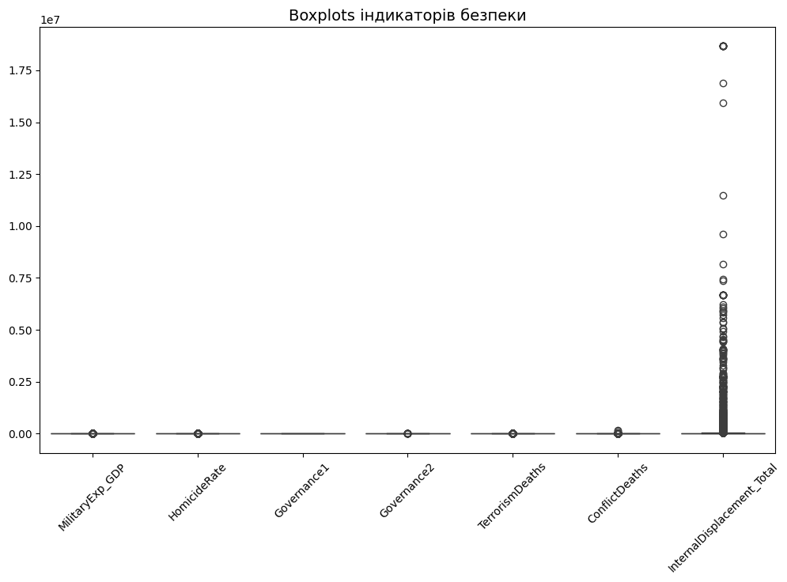

```python
# ---------------------------------------------------------
# 6.3 Boxplots індикаторів
# ---------------------------------------------------------

import matplotlib.pyplot as plt
import seaborn as sns

numeric_cols = [
    "MilitaryExp_GDP", "HomicideRate",
    "Governance1", "Governance2",
    "TerrorismDeaths", "ConflictDeaths",
    "InternalDisplacement_Total"
]

plt.figure(figsize=(12, 7))
sns.boxplot(data=df[numeric_cols])
plt.xticks(rotation=45)
plt.title("Boxplots індикаторів безпеки", fontsize=14)
plt.show()
```

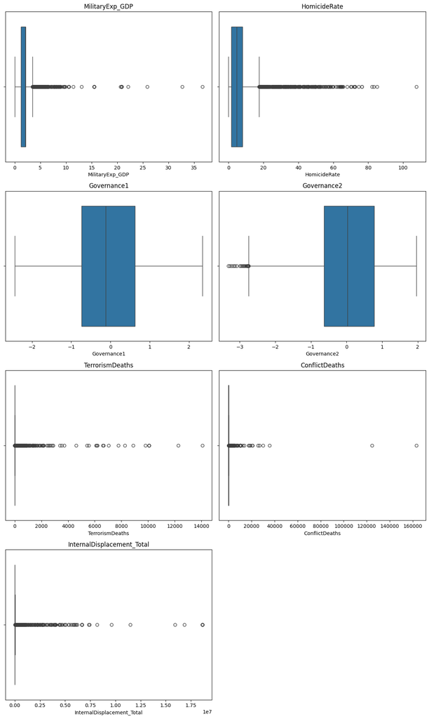

```python
# окремі boxplots для кожного індикатора
import seaborn as sns
import matplotlib.pyplot as plt

numeric_cols = [
    "MilitaryExp_GDP", "HomicideRate",
    "Governance1", "Governance2",
    "TerrorismDeaths", "ConflictDeaths",
    "InternalDisplacement_Total"
]

plt.figure(figsize=(12, 20))

for i, col in enumerate(numeric_cols, 1):
    plt.subplot(4, 2, i)
    sns.boxplot(x=df[col])
    plt.title(col)

plt.tight_layout()
plt.show()
```

### **Висновок**

Зведений boxplot неможливо інтерпретувати через величезний розрив масштабів між індикаторами  
(наприклад, Governance ~2, а InternalDisplacement_Total ~20 000 000).

Окремі boxplots дозволили коректно оцінити розподіл кожної змінної та виявити виброси.  
Це підтверджує необхідність нормалізації (StandardScaler) перед PCA та кластеризацією.

# Кореляційний аналіз індикаторів безпекового розвитку

Для розуміння взаємозв’язків між обраними індикаторами було проведено кореляційний аналіз.  
Кореляційна матриця дозволяє виявити:

- чи рухаються показники разом (позитивна кореляція);
- чи є між ними зворотний зв'язок (негативна кореляція);
- які індикатори можуть дублювати один одного;
- які змінні найбільш впливають на варіацію даних.

Цей етап є ключовим для подальших процедур нормалізації, вибору компонент (PCA) та кластеризації.

Нижче наведено теплову карту (heatmap) кореляцій між усіма кількісними індикаторами.

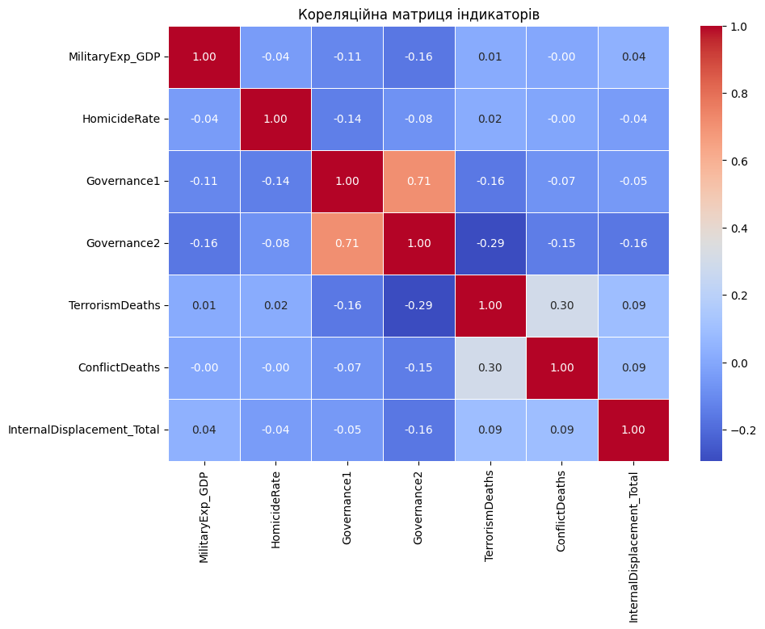

```python
import matplotlib.pyplot as plt
import seaborn as sns

plt.figure(figsize=(10, 7))
corr = df[[
    "MilitaryExp_GDP","HomicideRate","Governance1","Governance2",
    "TerrorismDeaths","ConflictDeaths","InternalDisplacement_Total"
]].corr()

sns.heatmap(corr, annot=True, cmap="coolwarm", fmt=".2f", linewidths=0.5)
plt.title("Кореляційна матриця індикаторів")
plt.show()
```

**Аналіз кореляційної матриці**

Решта індикаторів не мають сильного парного взаємозв'язку.

Варто зазначити, що Смертність від терроризму та від збройних конфліктів не сильно корелюють кількості переміщених осіб та гуманітарних наслідків. Можливо, це пов'язано з тим, що в епоху глобалізму є нормою переїжджати в інші країни на довгостроковий термін/назавжди через, наприклад, економічні фактори країни, звідки імігрують люди.